# Targets pipeline

### The Coursera Solution Pipeline[^1]

Full documentation for the rationale behind this implementation is in the ENDGAME.Rmd file.

The diagram for the pipeline which will allow iteration from cleaning and onwards is [here](https://docs.google.com/drawings/d/1ulZlV0PZG9nbkvX4l6Qm6_dJ9GT1m37ahK7CU9PbaNE/edit?usp=sharing) :

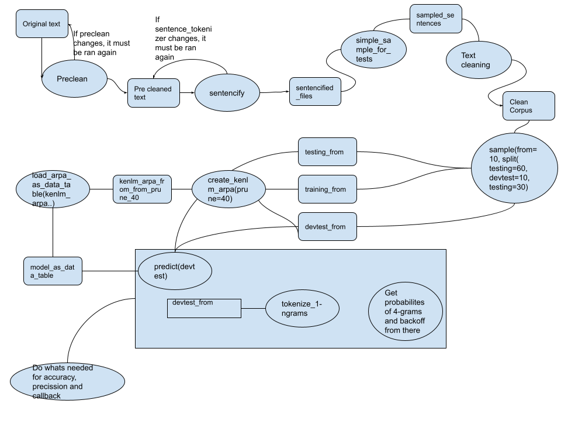

### Implementing the pipeline

#### Setup

Basic startup setup

```r
library(targets)
tar_unscript()
package_list <- c( "dplyr", "ggplot2", "readr", "tidyr","data.table","progressr","R6","pins","rsample","tidytext","purrr","furrr","magrittr","stringr","dtplyr")
xfun::pkg_attach(package_list)
options(tidyverse.quiet = TRUE)
targets::tar_option_set(format = 'qs')
targets::tar_option_set(packages = c( "dplyr", "ggplot2", "readr", "tidyr","data.table","progressr","R6","pins","rsample","tidytext","purrr","furrr","magrittr","stringr","dtplyr"))
source("R/global_variables.R")
```

```
#> Establish _targets.R and _targets_r/globals/t-globals.R.
```

#### Raw data definition

Files come very dirty. They need to be cleaned as pure text and using raw vectors. This is implemented in the preclean target.

However, further cleaning is necesary

```r
source("R/preclean_functions.R")
source("R/kenlm_functions.R")
source("R/sentencify.R")
# If you want to actually load the text into R, youd do this.
# list(tar_target(preclean,
#     preclean_files(
#     list.files(en_data_dir,pattern = '*.txt')),
#     format="file"
# ),
# tar_target(precleaned_text,
#     load_clean_text(),
#     format="qs"
# ))
#
# But we prefer generating the model with kenlm
#


list(
  tar_target(preclean,
             preclean_files(
               list.files(en_data_dir, pattern = '*.txt')
             ),
             format = "file"),
  tar_target(
    sentenced_files,
    sentencify(precleaned_files = preclean),

    format = "file"
  )
  # tar_target(single_cleantext_file,
  #            create_single_cleantext_file(
  #              source_files = tar_read(preclean)
  #            ),
  #            format="file"
  # ),
  #  tar_target(kenlm_arpa_file,
  #            create_kenlm_arpa(tar_read(single_cleantext_file)),
  #            format = 'file'),
  # tar_target(ngram_model,
  #            load_arpa_as_data_table(
  #              tar_read(kenlm_arpa_file)
  #            ))
  )
```

```
#> Establish _targets.R and _targets_r/targets/clean-target.R.
```

```r
tar_make()
```

```
#> ✓ skip target preclean
#> ✓ skip target sentenced_files
#> ✓ skip pipeline: 0.088 seconds
```

```r
tar_visnetwork()
```

[interactive chart not shown]

The interesting part comes to see if we change any of the functions, will it reload and recreate the precleaned_text? I went and changed stuff in the preclean_files function and sure enough, it works.

Many million rows…

```r
library(tidyverse)
library(dtplyr)
tar_target(
  preclean_summary,
 tar_read("precleaned_text")  %>%
  dtplyr::lazy_dt() %>%
  group_by(file=as_factor(file)) %>%
  as_tibble() %>%
  mutate(avlength=str_count(text)) %>%
  summary()
)
```

```
#> Establish _targets.R and _targets_r/targets/summary-precleaned-text-target.R.
```

Lets see this summary as a part of the pipeline:

```r
tar_make()
```

```
#> ✓ skip target preclean_summary
#> ✓ skip target preclean
#> ✓ skip target sentenced_files
#> ✓ skip pipeline: 0.095 seconds
```

```r
tar_visnetwork()
```

[interactive chart not shown]

```r
tar_read("preclean_summary")
```

```
#>     text_id                       file             text
#>  Min.   :      1   en_US.blogs.txt  : 899288   Length:4269678
#>  1st Qu.: 355807   en_US.news.txt   :1010242   Class :character
#>  Median : 711614   en_US.twitter.txt:2360148   Mode  :character
#>  Mean   : 866530
#>  3rd Qu.:1292729
#>  Max.   :2360148
#>     avlength
#>  Min.   :    0.0
#>  1st Qu.:   44.0
#>  Median :   88.0
#>  Mean   :  133.7
#>  3rd Qu.:  153.0
#>  Max.   :40832.0
```

#### Setencifying the text

```r
source("R/sentencify.R")
# tar_target(
#   corpus,
#   tar_read("precleaned_text") %>% sentencify()
# )
```

```
#> Establish _targets.R and _targets_r/targets/sentecify-target.R.
```

```r
tar_make()
```

```
#> ✓ skip target preclean_summary
#> ✓ skip target preclean
#> ✓ skip target sentenced_files
#> ✓ skip pipeline: 0.098 seconds
```

```r
tar_visnetwork()
```

[interactive chart not shown]

[^1]: For reference the oficial manual is: https://books.ropensci.org/targets/markdown.html#target-markdown